# Machine learning Week 4

## Running the model

Now we can start our prediction, we’ll make a model to predict classe with all possible predictors. Our method will be “rf” (random forest) and we’ll use the train control we defined in the previous section. Because my patience only goes so far, I’ve also enabled a parallel processing session with the DoMC library. And now let’s start the training….

```r
#Perform parallel processing with 3 cores
registerDoMC(cores=3)
#Make a random forests model
modrf  <- train(classe ~ ., data=training, method = "rf", trControl = trcl)
```

…  
…  
…  
..  
.

I forgot to mention that another downside of random forests is that it takes so LONG for them to finish!. But finally we’re done. Just out of curiosity how long did it take?

```r
modrf$times$everything
```

```
##    user  system elapsed
## 573.744   2.036 332.355
```

Wow.. Good thing I enabled the multicore or I would be here a whole lot longer. The difference bewtween user and elapsed shows that multicore allowed a speed increase. But of course the real question is, how accurate is our model? Let’s take a look?

```r
modrf
```

```
## Random Forest
##
## 13737 samples
##    59 predictors
##     5 classes: 'A', 'B', 'C', 'D', 'E'
##
## No pre-processing
## Resampling: Cross-Validated (5 fold)
## Summary of sample sizes: 10989, 10990, 10990, 10989, 10990
## Resampling results across tuning parameters:
##
##   mtry  Accuracy   Kappa
##    2    0.9977433  0.9971456
##   32    0.9999272  0.9999079
##   63    0.9998544  0.9998159
##
## Accuracy was used to select the optimal model using  the largest value.
## The final value used for the model was mtry = 32.
```

Looks like we got an accuracy of more than 99%. That’s very good as far as I’m concerned. Now let’s also take a look at our final model.

```r
modrf$finalModel
```

```
##
## Call:
##  randomForest(x = x, y = y, mtry = param$mtry)
##                Type of random forest: classification
##                      Number of trees: 500
## No. of variables tried at each split: 32
##
##         OOB estimate of  error rate: 0.01%
## Confusion matrix:
##      A    B    C    D    E  class.error
## A 3906    0    0    0    0 0.0000000000
## B    1 2657    0    0    0 0.0003762227
## C    0    0 2396    0    0 0.0000000000
## D    0    0    0 2252    0 0.0000000000
## E    0    0    0    0 2525 0.0000000000
```

That’s not bad at all! An error rate of less than 0.1%! Of course this is just from the cross validation. The problem with a small k-fold is that we have more bias in our model training. So how does it perform against our untouched test set? We’ll set up a confusion matrix with the test$classe variable and the answer from our predictions…

## Testing the model

```r
confusionMatrix(test$classe, predict(modrf, test))$overall
```

```
##       Accuracy          Kappa  AccuracyLower  AccuracyUpper   AccuracyNull
##      0.9998301      0.9997851      0.9990536      0.9999957      0.2844520
## AccuracyPValue  McnemarPValue
##      0.0000000            NaN
```

Still not bad! An accuracy of 99.98%! Normally I like to plaster my assignments with lots of charts, but I haven’t really been able to do that so far. So let’s create a chart to show of our performance. Here’s our confusion matrix in pretty colors:

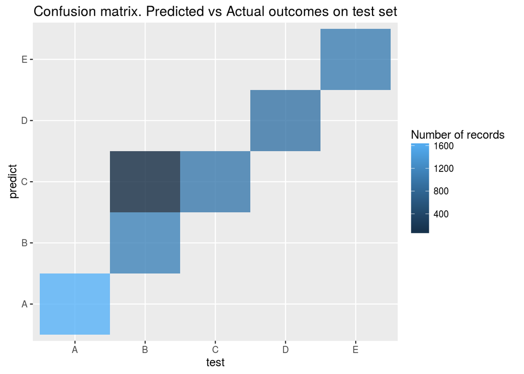

```r
library(dplyr)
dt <- data.frame(test = test$classe, predict = predict(modrf, test)) %>%
    group_by( test, predict) %>%
    tally()
g  <- ggplot(data=dt, aes(x=test, y=predict))
g <- g + geom_tile(aes(fill=n), alpha=0.8)
g <- g + ggtitle("Confusion matrix. Predicted vs Actual outcomes on test set")
g <- g + scale_fill_continuous(name = "Number of records")
print(g)
```

## Conclusion

A possible improvement could be to take the timeseries as a whole and to use it for the prediction. It might make it easier on the model building. But for now I’m satisfied with the results.